# MTH6139 Sunspots Time Series

Coursework 1 – Sunspots Time Series Analysis Using Prophet

Elizabeth Gilmartin

Spring term 2025

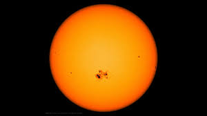

# Introduction

Sunspots are dark spots visible on the Sun’s photosphere. They are caused by strong magnetic fields which prevent heat from flowing to the Sun’s surface. Understanding the time series associated with the number of visible sunspots is important in tracking the Sun’s 11 year natural cycle. At the beginning of each 11 year cycle, the Sun’s magentic poles flip. As a result, solar activity increases and so does the number of sunspots. Tracking the number of sunspots through time helps scientists predict how solar activity may impact spacecraft and astronauts. This project aims to predict the overall trend of solar activity using Meta’s Prophet. The dataset was downloaded from https://www.kaggle.com/datasets/abhinand05/daily-sun-spot-data-1818-to-2019.

# Section 1: Data Set up

## 1.1 Packages Used

In this project, I use the following packages: - astsa - dplyr - prophet - remotes

## 1.3 Loading the Data

First let’s load the data from our csv file into a data frame in R.

```r
SunData = read.csv("data/sunspot_data.csv")
head(SunData)
```

```
##   X Year Month Day Date.In.Fraction.Of.Year Number.of.Sunspots
## 1 0 1818     1   1                 1818.001                 -1
## 2 1 1818     1   2                 1818.004                 -1
## 3 2 1818     1   3                 1818.007                 -1
## 4 3 1818     1   4                 1818.010                 -1
## 5 4 1818     1   5                 1818.012                 -1
## 6 5 1818     1   6                 1818.015                 -1
##   Standard.Deviation Observations Indicator
## 1                 -1            0         1
## 2                 -1            0         1
## 3                 -1            0         1
## 4                 -1            0         1
## 5                 -1            0         1
## 6                 -1            0         1
```

```r
tail(SunData)
```

```
##           X Year Month Day Date.In.Fraction.Of.Year Number.of.Sunspots
## 73713 73712 2019    10  26                 2019.818                  0
## 73714 73713 2019    10  27                 2019.821                  0
## 73715 73714 2019    10  28                 2019.823                  0
## 73716 73715 2019    10  29                 2019.826                  0
## 73717 73716 2019    10  30                 2019.829                  0
## 73718 73717 2019    10  31                 2019.832                  0
##       Standard.Deviation Observations Indicator
## 73713                  0           35         0
## 73714                  0           34         0
## 73715                  0           34         0
## 73716                  0           30         0
## 73717                  0           24         0
## 73718                  0           28         0
```

# Section 2: Cleaning the Data and Prep for Analysis

Although the data is oaded into a data frame, it needs to be filtered before it can be analyzed. A value -1 in the column `{r}Number.of.Sunspots` indicates that there is no data recorded for that day. So these rows without valid data must be filtered out. This is done by running:

```r
filtered_SunData = SunData[SunData$Number.of.Sunspots >= 0,]
head(filtered_SunData)
```

```
##     X Year Month Day Date.In.Fraction.Of.Year Number.of.Sunspots
## 8   7 1818     1   8                 1818.021                 65
## 13 12 1818     1  13                 1818.034                 37
## 17 16 1818     1  17                 1818.045                 77
## 18 17 1818     1  18                 1818.048                 98
## 19 18 1818     1  19                 1818.051                105
## 25 24 1818     1  25                 1818.067                 25
##    Standard.Deviation Observations Indicator
## 8                10.2            1         1
## 13                7.7            1         1
## 17               11.1            1         1
## 18               12.6            1         1
## 19               13.0            1         1
## 25                6.3            1         1
```

```r
tail(filtered_SunData)
```

```
##           X Year Month Day Date.In.Fraction.Of.Year Number.of.Sunspots
## 73713 73712 2019    10  26                 2019.818                  0
## 73714 73713 2019    10  27                 2019.821                  0
## 73715 73714 2019    10  28                 2019.823                  0
## 73716 73715 2019    10  29                 2019.826                  0
## 73717 73716 2019    10  30                 2019.829                  0
## 73718 73717 2019    10  31                 2019.832                  0
##       Standard.Deviation Observations Indicator
## 73713                  0           35         0
## 73714                  0           34         0
## 73715                  0           34         0
## 73716                  0           30         0
## 73717                  0           24         0
## 73718                  0           28         0
```

Before moving on to visualizing the data, we’ll first group the data and calculate the average number of sunspots per year and also per month to better visualize the Sun’s 11 year cycle.

```r
library(dplyr)
#group by year and calculate yearly average
AverageSunspotDataYearly = filtered_SunData %>% #stores our grouped data in a new data frame
    group_by(Year) %>% #this groups the data by year
    summarise(mean_Sunspots = mean(Number.of.Sunspots)) #this takes an average of the number of sunspots per year

# Group by Year and Month, then calculate the average of 'Value'
AveSunspotsMonthly = filtered_SunData %>%
    group_by(Year, Month) %>%  # Group by Year and Month
    summarise(AverageValue = mean(Number.of.Sunspots))  # Compute the average of 'Value'
```

```r
AveSunspotsMonthly$Date = as.Date(paste(AveSunspotsMonthly$Year, AveSunspotsMonthly$Month, "01", sep = "-"))
#make the data easy to plot by converting to ts:
ts_AveSunspotsMonthly = ts(AveSunspotsMonthly$AverageValue, start = c(1818,1), frequency = 12)
```

# Section 2: Visualizing Data

Now that the data has been filtered and grouped, it can be plotted to indicate what trends to expect, what the periodicity of the time series looks like, and how volatile the data is.

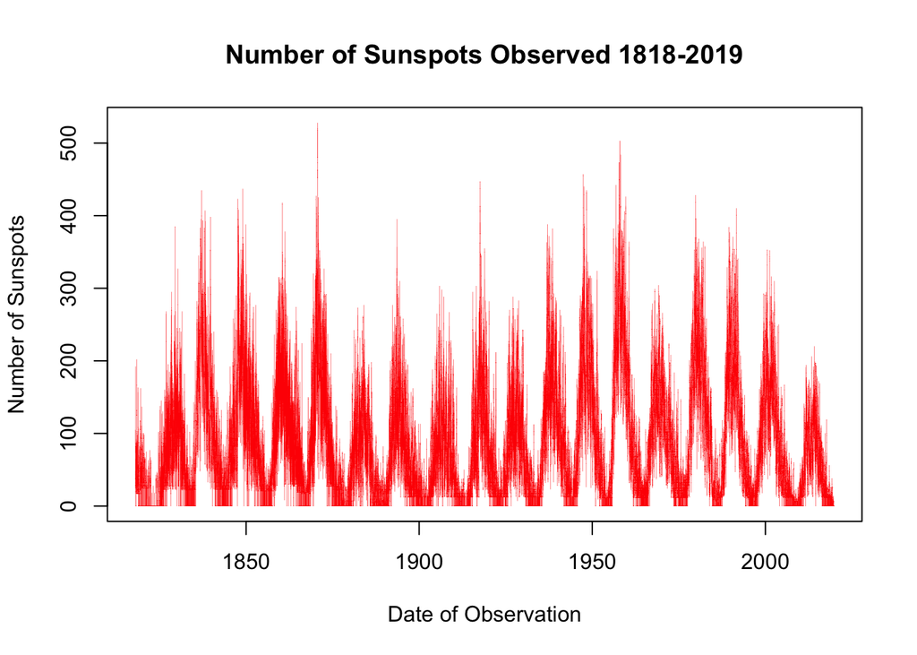

```r
plot(filtered_SunData$Date.In.Fraction.Of.Year, filtered_SunData$Number.of.Sunspots,
     type='l', lwd = 0.2,col="red", main = 'Number of Sunspots Observed 1818-2019', xlab = "Date of Observation", ylab = "Number of Sunspots")
```

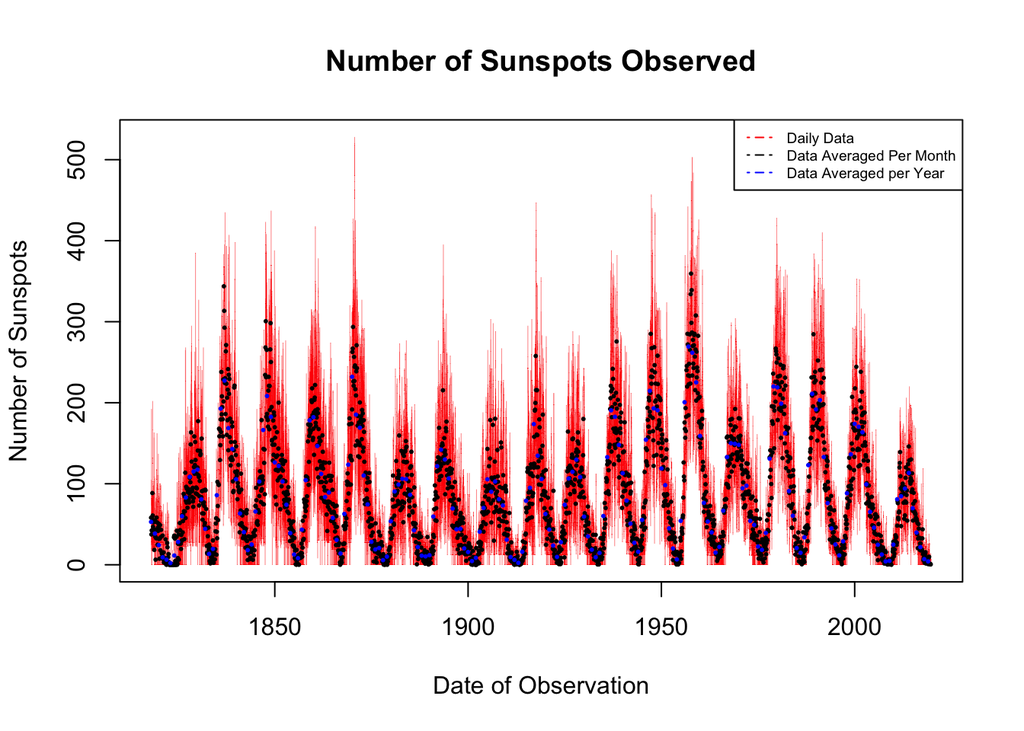

```r
plot(filtered_SunData$Date.In.Fraction.Of.Year, filtered_SunData$Number.of.Sunspots,
     type='l', lwd = 0.2,col="red", main = "Number of Sunspots Observed", xlab = "Date of Observation", ylab = "Number of Sunspots")
points(ts_AveSunspotsMonthly,pch=20, cex=0.4,col="black")
points(AverageSunspotDataYearly, pch=20, cex = 0.4, col="blue") #visualize output
legend("topright",
       legend = c("Daily Data", "Data Averaged Per Month", "Data Averaged per Year"),  # Text for each item in the legend
       col = c("red", "black","blue"),      # Color of the points/lines in the plot
       cex = 0.6,                  # Control text size (smaller text)
    lty = 4)              # Line type (if it's a line plot)
```

Both the monthly and yearly averaged data appears to be less volatile and may provide better results when using prophet to forecast the number of sunspots in the future.

# Section 3: Using Prophet to Forecast the Number of Sunspots

Meta’s Prophet forecasting system requires the data to be in an R `dataframe` where the time coulmn is named ds and the data column is named y. Then after creating future dates for prophet to use in its forecast, the function `predict` prompts prophet to forecast the data.

## 3.1 Forecast using Daily Data

```r
SunSpots.df = data.frame(ds = zoo::as.yearmon(filtered_SunData$Date.In.Fraction.Of.Year),
    y=filtered_SunData$Number.of.Sunspots)
SunSpots.df$cap = 100  # Set the cap (upper bound of sunspots)
SunSpots.df$floor = 0  # Set the floor (lower bound of sunspots)
m = prophet::prophet(SunSpots.df, changepoint.prior.scale = 0.05, growth = 'logistic')
```

```
## Disabling weekly seasonality. Run prophet with weekly.seasonality=TRUE to override this.
```

```
## Disabling daily seasonality. Run prophet with daily.seasonality=TRUE to override this.
```

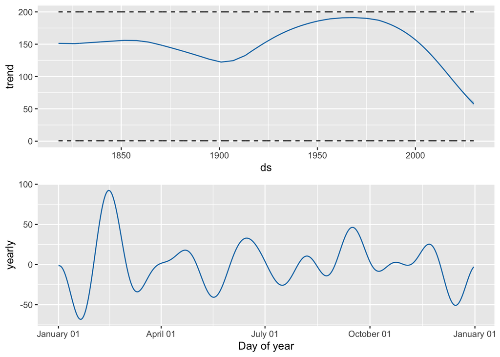

```r
f = prophet::make_future_dataframe(m, periods = 10, freq = 'year') #make future dates for prediction
f$cap = 200  # Cap for the future predictions needed fro logistic prediction
f$floor = 0.5   # Floor for the future predictions needed fro logistic prediction
Prediction = predict(m,f)
prophet::prophet_plot_components(m, Prediction)
```

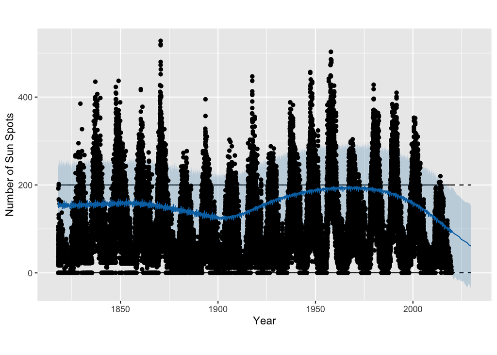

```r
plot(m,Prediction, ,type = 'line', xlab="Year", ylab='Number of Sun Spots')
```

## 3.2 Forecast Using Monthly Averages

Let’s see if using the data that was averaged monthly yield different results.

```r
#store our data in a data frame prophet can read
AveSunspotsMonthly.df = data.frame(ds = zoo::as.yearmon(AveSunspotsMonthly$Year),
                         y=AveSunspotsMonthly$AverageValue)
AveSunspotsMonthly.df$cap = 500  # Set the cap (upper bound of sunspots)
AveSunspotsMonthly.df$floor = 0  # Set the floor (lower bound of sunspots)
# calculate the trend
m = prophet::prophet(AveSunspotsMonthly.df, changepoint.prior.scale = 0.05, growth = 'logistic')
```

```
## Disabling weekly seasonality. Run prophet with weekly.seasonality=TRUE to override this.
```

```
## Disabling daily seasonality. Run prophet with daily.seasonality=TRUE to override this.
```

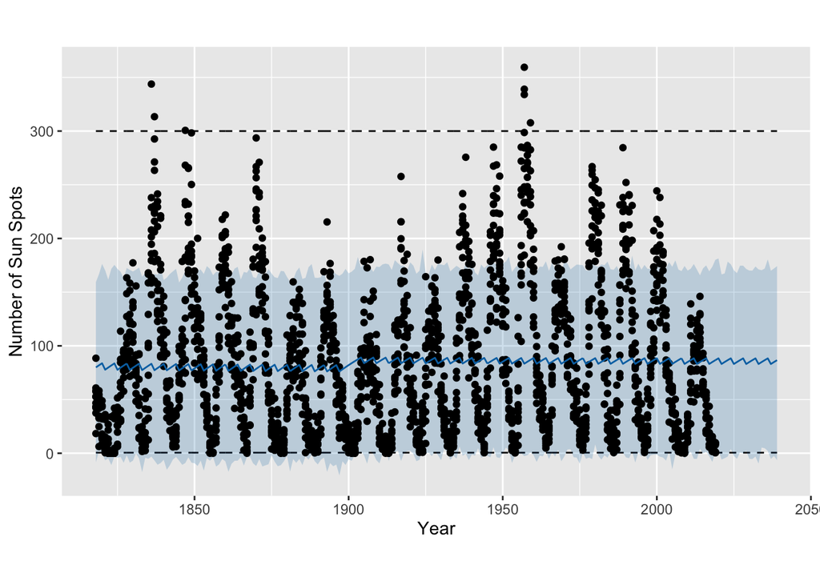

```r
#calculate future dates fro prophet to use in its prediction
f = prophet::make_future_dataframe(m, periods = 20, freq = 'year') #make future dates for prediction
f$cap = 300  # Cap for the future predictions needed for logistic prediction
f$floor = 0.5   # Floor for the future predictions needed fro logistic prediction
#run a prediction of future number of sunspots
Prediction = predict(m,f)
# plot the data and prediction
plot(m,Prediction, ,type = 'line', main = 'Prophet', xlab="Year", ylab='Number of Sun Spots')
```

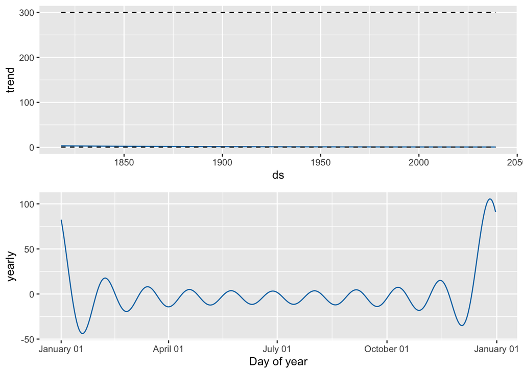

```r
prophet::prophet_plot_components(m, Prediction)
```

Using the monthly averaged data yields a straight line for our trend. This is not a very useful forecast because it does not capture the rise and fall of the number of sunspots during each 11-year cycle.

## 3.3 Forecast Using Yearly Averages

Now we will see what the prophet forecast looks like when we average the number of sunspots each year.

```r
#first select dates we want to use in prediction
FilteredAverageSunspotDataYearly = AverageSunspotDataYearly[AverageSunspotDataYearly$Year>=1818,]
#store our data in a data frame prophet can read
AveSunspotsYearly.df = data.frame(ds = zoo::as.yearmon(FilteredAverageSunspotDataYearly$Year),
                         y=FilteredAverageSunspotDataYearly$mean_Sunspots)
AveSunspotsYearly.df$cap = 500  # Set the cap (upper bound of sunspots)
AveSunspotsYearly.df$floor = 0  # Set the floor (lower bound of sunspots)
# calculate the trend
m = prophet::prophet(AveSunspotsYearly.df, changepoint.prior.scale = 0.05, growth = 'logistic')
```

```
## Disabling weekly seasonality. Run prophet with weekly.seasonality=TRUE to override this.
```

```
## Disabling daily seasonality. Run prophet with daily.seasonality=TRUE to override this.
```

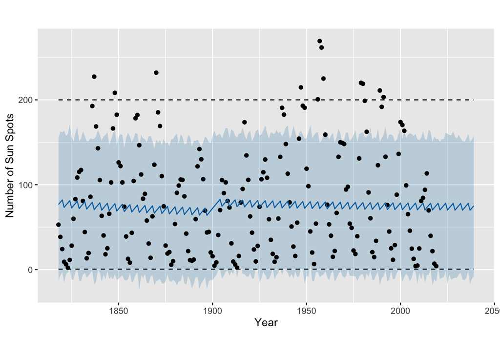

```r
#calculate future dates fro prophet to use in its prediction
f = prophet::make_future_dataframe(m, periods = 20, freq = 'year') #make future dates for prediction
f$cap = 200  # Cap for the future predictions needed fro logistic prediction
f$floor = 0.5   # Floor for the future predictions needed fro logistic prediction
#run a prediction of future number of sunspots
Prediction = predict(m,f)
# plot the data and prediction
plot(m,Prediction, ,type = 'line', main = 'Prophet', xlab="Year", ylab='Number of Sun Spots')
```

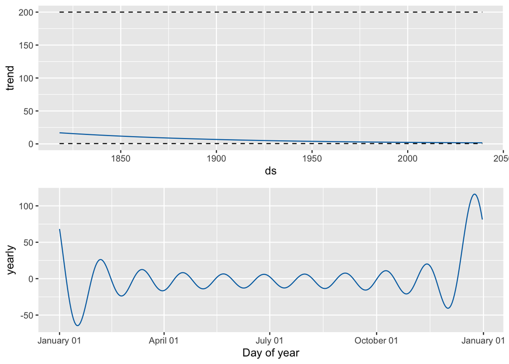

```r
prophet::prophet_plot_components(m, Prediction)
```

Similar to what happened with the monthly averaged data, prophet forecast a flat line. Again, this is because prophet cannot recognize periodic behavior of data when the period is over a year. So instead, we are left with a line that best fits the data.

## 3.4 Summary

# Section 4: The Sun’s 11 year cycle

Since Prophet cannot detect seasonality with periods longer than 1 year, I researched alternative ways to visualize and verify the 11 year cycle of the Sun.

First plot to view the data series again:

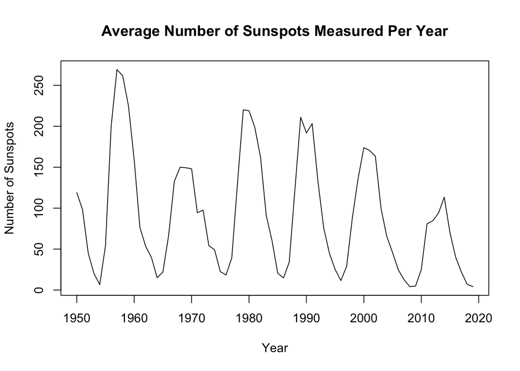

```r
plot(AverageSunspotDataYearly[AverageSunspotDataYearly$Year>=1950,], type="line", xlab="Year", ylab="Number of Sunspots", main = "Average Number of Sunspots Measured Per Year") #visualize output
```

Now we will investigate the 11 year cycle using a periodogram. A periodogram indicates strong frequencies in the data by estimating spectral density. Spectral density is a frequency domain representation of a time series, so the peaks indicate the prominent frequencies of our time series. Plotting a periodogram of our data will allow us to confirm the 11 year cycle of the Sun. First we will smooth our data using the Daniell Kernel. This is a centered moving average. For this project, we will use the parameter m = 4 which corresponds to a 9-point centered moving average. Next, we will use the command mvspec to estimate and plot the spectral density of our now smoothed time series. We see a large peak on the left of the graph which corresponds to the dominant frequency of our sunspot data. To confirm that this is the 11 year cycle, we overlay a line on the graph at the frequency 1/132 where 132 represents 12 months times 11 years. The line plotted at the frequency for 11 years matches the peak of our spectral density. This is confirmation that the Sun has an 11 year cycle. The code is as follows:

```r
k = kernel("daniell", 4) #This is a 9-point centered moving average
astsa::mvspec(AveSunspotsMonthly$AverageValue, k, log="no")
```

```
## Bandwidth: 0.004 | Degrees of Freedom: 17.93 | split taper: 0%
```

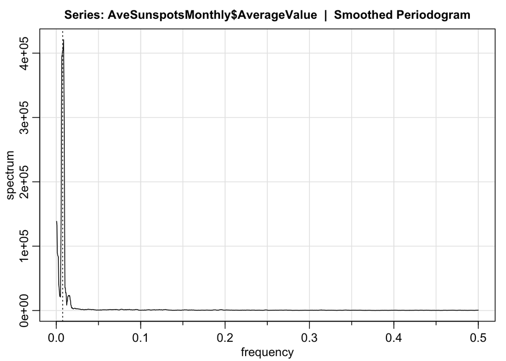

```r
abline(v=1/132, lty="dotted")
```

# References

- Data Source: https://www.kaggle.com/datasets/abhinand05/daily-sun-spot-data-1818-to-2019
- Prophet reference: https://facebook.github.io/prophet/docs/quick_start.html#r-api
- Sunspot Reference: https://science.nasa.gov/sun/sunspots/
- Spectral Density Reference: https://online.stat.psu.edu/stat510/lesson/12/12.1#:~:text=The%20spectral%20density%20is%20a,express%20it%20in%20different%20ways.